# Single Cell - Example analysis

Miłosz Chodkowski

# Experiment summary

Dataset of induced pluripotent stem cells generated from three different individuals (Tung et al. 2017) in Yoav Gilad’s lab at the University of Chicago. The experiments were carried out on the Fluidigm C1 platform using unique molecular identifiers (UMIs) for quantification.

GEO Accession: *GSE77288*

# R packages

> “How hard can it be?” *~ Jeremy Clarkson*

## Load libraries

```r
if(!require("SingleCellExperiment")){
  BiocManager::install("SingleCellExperiment")
  require("SingleCellExperiment")
}
if(!require("scater")){
  BiocManager::install("scater")
}
if(!require("scuttle")){
  BiocManager::install("scuttle")
}
if(!require("tidyverse")){
  install.packages("tidyverse")
  library("tidyverse")
}
if(!require("data.table")){
  install.packages("data.table")
}
```

## Load data

Original file called

```r
df = data.table::fread("GSE77288_molecules-raw-single-per-sample.txt.gz")
df[1:5, 1:5]
```

```
##    individual replicate well ENSG00000186092 ENSG00000237683
## 1:    NA19098        r1  A01               0               0
## 2:    NA19098        r1  A02               0               0
## 3:    NA19098        r1  A03               0               0
## 4:    NA19098        r1  A04               0               1
## 5:    NA19098        r1  A05               0               0
```

Splitted into molecules (a tab-delimited file with the gene counts for each cell):

```r
molecules = read.table("data/tung/molecules.txt", sep = "\t")

molecules[1:5, 1:5]
```

```
##                 NA19098.r1.A01 NA19098.r1.A02 NA19098.r1.A03 NA19098.r1.A04 NA19098.r1.A05
## ENSG00000237683              0              0              0              1              0
## ENSG00000187634              0              0              0              0              0
## ENSG00000188976              3              6              1              3              4
## ENSG00000187961              0              0              0              0              0
## ENSG00000187583              0              0              0              0              0
```

And annotation for molecules (a tab-delimited text file with the cell annotations)

```r
annotation = read.table("data/tung/annotation.txt", sep = "\t", header = TRUE)
annotation[1:5, 1:5]
```

```
##   individual replicate well      batch      sample_id
## 1    NA19098        r1  A01 NA19098.r1 NA19098.r1.A01
## 2    NA19098        r1  A02 NA19098.r1 NA19098.r1.A02
## 3    NA19098        r1  A03 NA19098.r1 NA19098.r1.A03
## 4    NA19098        r1  A04 NA19098.r1 NA19098.r1.A04
## 5    NA19098        r1  A05 NA19098.r1 NA19098.r1.A05
```

## Create object of type `SingleCellExperiment`

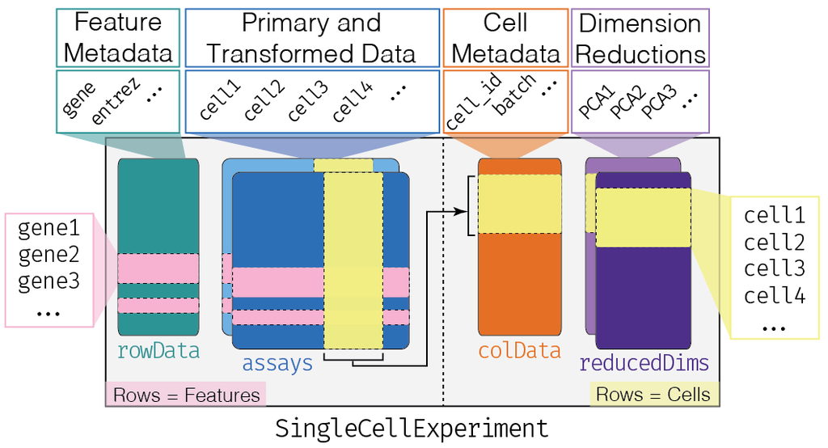

SingleCellExperiment obj schema

Object `SingleCellExperiment` uses a very popular `SummarizedExperiment` object (used in all biological anlyses). We pass a list to the `assays` argument in which we give our molecules data as `counts`. Then we add a `colData` parameter to describe our *samples*. We can optionally add `rowData` which is a parameter to describe our *genes.*

```r
experiment = SingleCellExperiment(
  assays = list(counts = as.matrix(molecules)), # Type required is matrix, list passed as kwargs to `SummarizedExperiment)
  colData = annotation # Can be table
)
experiment
```

```
## class: SingleCellExperiment
## dim: 19027 864
## metadata(0):
## assays(1): counts
## rownames(19027): ENSG00000237683 ENSG00000187634 ... ERCC-00170 ERCC-00171
## rowData names(0):
## colnames(864): NA19098.r1.A01 NA19098.r1.A02 ... NA19239.r3.H11 NA19239.r3.H12
## colData names(5): individual replicate well batch sample_id
## reducedDimNames(0):
## mainExpName: NULL
## altExpNames(0):
```

According to schema, data describing our samples are in colData. Let’s see it:

```r
colData(experiment)
```

```
## DataFrame with 864 rows and 5 columns
##                 individual   replicate        well       batch      sample_id
##                <character> <character> <character> <character>    <character>
## NA19098.r1.A01     NA19098          r1         A01  NA19098.r1 NA19098.r1.A01
## NA19098.r1.A02     NA19098          r1         A02  NA19098.r1 NA19098.r1.A02
## NA19098.r1.A03     NA19098          r1         A03  NA19098.r1 NA19098.r1.A03
## NA19098.r1.A04     NA19098          r1         A04  NA19098.r1 NA19098.r1.A04
## NA19098.r1.A05     NA19098          r1         A05  NA19098.r1 NA19098.r1.A05
## ...                    ...         ...         ...         ...            ...
## NA19239.r3.H08     NA19239          r3         H08  NA19239.r3 NA19239.r3.H08
## NA19239.r3.H09     NA19239          r3         H09  NA19239.r3 NA19239.r3.H09
## NA19239.r3.H10     NA19239          r3         H10  NA19239.r3 NA19239.r3.H10
## NA19239.r3.H11     NA19239          r3         H11  NA19239.r3 NA19239.r3.H11
## NA19239.r3.H12     NA19239          r3         H12  NA19239.r3 NA19239.r3.H12
```

We didn’t specify any additional information for our genes, so rowData should be an empty df with named rows only:

```r
print(rowData(experiment))
```

```
## DataFrame with 19027 rows and 0 columns
```

```r
print(rowData(experiment) %>% rownames() %>% head(5)) # First 5 genes
```

```
## [1] "ENSG00000237683" "ENSG00000187634" "ENSG00000188976" "ENSG00000187961" "ENSG00000187583"
```

## Some stats

```r
# Add a new assay that was log transformed
# We can use `assay(sce, "assay_name")<-` to get or set a new assay
# Or we can use some predefined functions with predefined names
# Examples: `counts` - raw counts, `normcounts` - normalized counts, `logcounts` - logtransformed counts, `tpm` - transcripts per million, etc.

# We already have raw counts
# counts(experiment)

# So just set new logcounts3
logcounts(experiment) <- log2(counts(experiment) + 1) # Add 1 to prevent log(0) = -Inf
logcounts(experiment)[1:5, 1:5]
```

```
##                 NA19098.r1.A01 NA19098.r1.A02 NA19098.r1.A03 NA19098.r1.A04 NA19098.r1.A05
## ENSG00000237683              0       0.000000              0              1       0.000000
## ENSG00000187634              0       0.000000              0              0       0.000000
## ENSG00000188976              2       2.807355              1              2       2.321928
## ENSG00000187961              0       0.000000              0              0       0.000000
## ENSG00000187583              0       0.000000              0              0       0.000000
```

```r
# We can also use another method from another package that just works on SingleCellExperiment obj
experiment = scuttle::logNormCounts(experiment)
```

We can also add some mean count and total count per cell

```r
print(counts(experiment)[1:5, 1:5])
```

```
##                 NA19098.r1.A01 NA19098.r1.A02 NA19098.r1.A03 NA19098.r1.A04 NA19098.r1.A05
## ENSG00000237683              0              0              0              1              0
## ENSG00000187634              0              0              0              0              0
## ENSG00000188976              3              6              1              3              4
## ENSG00000187961              0              0              0              0              0
## ENSG00000187583              0              0              0              0              0
```

```r
cat("\n\n")
```

```r
print(colMeans(counts(experiment)[1:5, 1:5]))
```

```
## NA19098.r1.A01 NA19098.r1.A02 NA19098.r1.A03 NA19098.r1.A04 NA19098.r1.A05
##            0.6            1.2            0.2            0.8            0.8
```

```r
cat("\n\n")
```

```r
colData(experiment)$mean_counts = colMeans(counts(experiment))
colData(experiment)$total_counts = colSums(counts(experiment))
cat("\n\n")
```

```r
print(colData(experiment)[1:5, ])
```

```
## DataFrame with 5 rows and 8 columns
##                 individual   replicate        well       batch      sample_id sizeFactor mean_counts
##                <character> <character> <character> <character>    <character>  <numeric>   <numeric>
## NA19098.r1.A01     NA19098          r1         A01  NA19098.r1 NA19098.r1.A01   0.929460     3.32801
## NA19098.r1.A02     NA19098          r1         A02  NA19098.r1 NA19098.r1.A02   0.939060     3.36238
## NA19098.r1.A03     NA19098          r1         A03  NA19098.r1 NA19098.r1.A03   0.640415     2.29306
## NA19098.r1.A04     NA19098          r1         A04  NA19098.r1 NA19098.r1.A04   0.791484     2.83397
## NA19098.r1.A05     NA19098          r1         A05  NA19098.r1 NA19098.r1.A05   1.040501     3.72560
##                total_counts
##                   <numeric>
## NA19098.r1.A01        63322
## NA19098.r1.A02        63976
## NA19098.r1.A03        43630
## NA19098.r1.A04        53922
## NA19098.r1.A05        70887
```

## Visual presentation

This is utterly f****** disgusting *~ Python programmer when he saw the R plotting code*

Let’s plot some stats for each batch:

```r
cells = colData(experiment) %>% as.data.frame() # convert from c(Data.frame, SingleCellExperiment) to data.frame
print(cells[1:5, 1:5])
```

```
##                individual replicate well      batch      sample_id
## NA19098.r1.A01    NA19098        r1  A01 NA19098.r1 NA19098.r1.A01
## NA19098.r1.A02    NA19098        r1  A02 NA19098.r1 NA19098.r1.A02
## NA19098.r1.A03    NA19098        r1  A03 NA19098.r1 NA19098.r1.A03
## NA19098.r1.A04    NA19098        r1  A04 NA19098.r1 NA19098.r1.A04
## NA19098.r1.A05    NA19098        r1  A05 NA19098.r1 NA19098.r1.A05
```

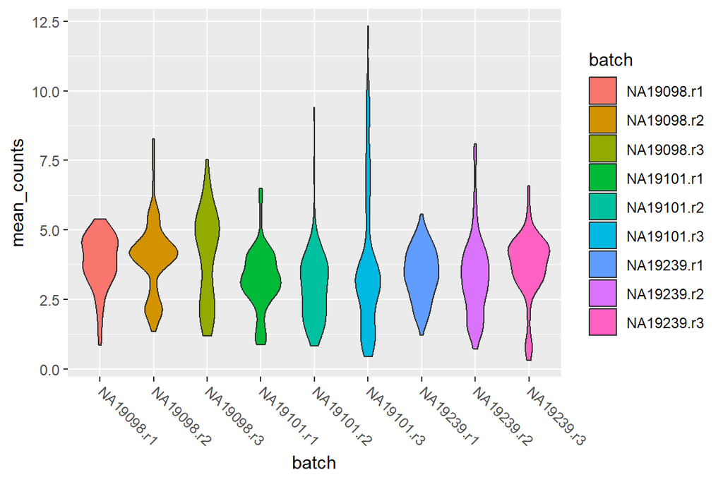

```r
th = theme(axis.text.x  = element_text(angle = -45, hjust = -0.1))

p = ggplot(data = cells)
p + geom_violin(aes(x = batch, mean_counts, fill = batch)) + th
```

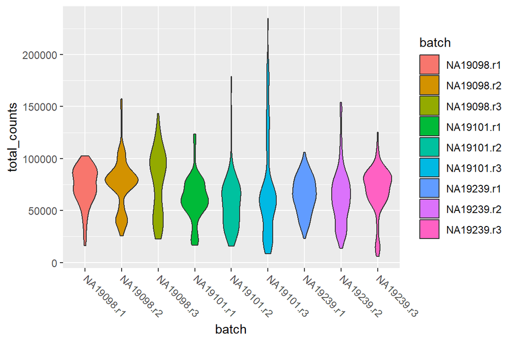

```r
p + geom_violin(aes(x = batch, total_counts, fill = batch)) + th
```

If we we want to plot some data from specific assay showing a specific *GENE*, then we can use `ggcells` function from `scater` package:

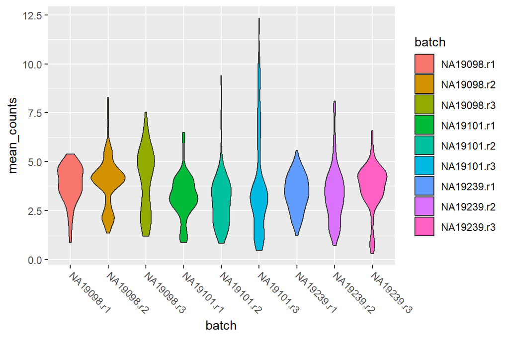

```r
# Using scater's ggcells we can give a SingleCellExperiment instead of data.frame
# Above example using scater
scater::ggcells(experiment, aes(x = batch, y = mean_counts, fill = batch)) + geom_violin() + th
```

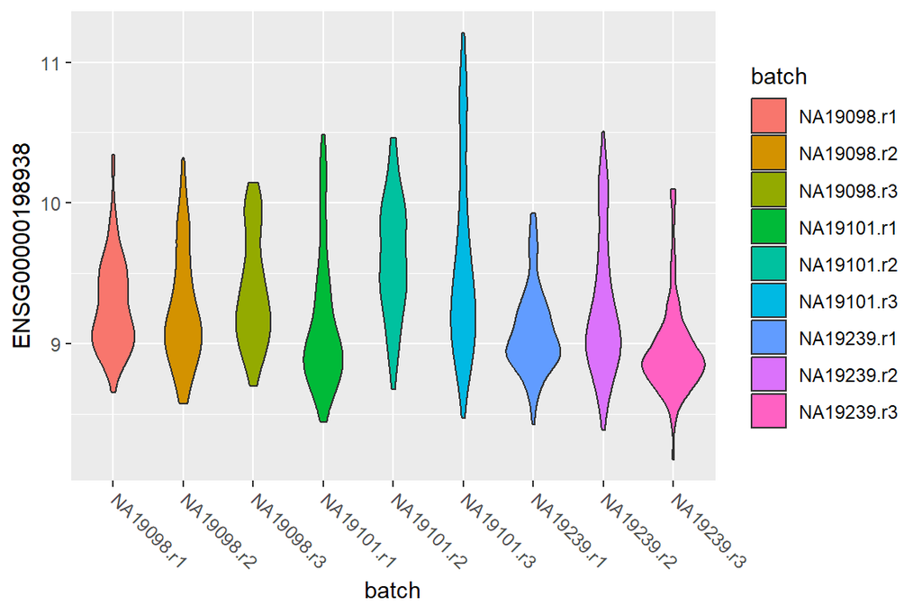

```r
# individual gene
# expr_values default = logcounts
scater::ggcells(experiment, aes(x = batch, y = ENSG00000198938, fill = batch), exprs_values = "logcounts") + geom_violin() + th
```

```r
# And scatter plot
# First calculate in each sample
colData(experiment)$var_counts <- colVars(counts(experiment))
colData(experiment)
```

```
## DataFrame with 864 rows and 9 columns
##                 individual   replicate        well       batch      sample_id sizeFactor mean_counts
##                <character> <character> <character> <character>    <character>  <numeric>   <numeric>
## NA19098.r1.A01     NA19098          r1         A01  NA19098.r1 NA19098.r1.A01   0.929460     3.32801
## NA19098.r1.A02     NA19098          r1         A02  NA19098.r1 NA19098.r1.A02   0.939060     3.36238
## NA19098.r1.A03     NA19098          r1         A03  NA19098.r1 NA19098.r1.A03   0.640415     2.29306
## NA19098.r1.A04     NA19098          r1         A04  NA19098.r1 NA19098.r1.A04   0.791484     2.83397
## NA19098.r1.A05     NA19098          r1         A05  NA19098.r1 NA19098.r1.A05   1.040501     3.72560
## ...                    ...         ...         ...         ...            ...        ...         ...
## NA19239.r3.H08     NA19239          r3         H08  NA19239.r3 NA19239.r3.H08  0.8651836    3.097861
## NA19239.r3.H09     NA19239          r3         H09  NA19239.r3 NA19239.r3.H09  0.8192992    2.933568
## NA19239.r3.H10     NA19239          r3         H10  NA19239.r3 NA19239.r3.H10  0.0884809    0.316813
## NA19239.r3.H11     NA19239          r3         H11  NA19239.r3 NA19239.r3.H11  0.7480947    2.678615
## NA19239.r3.H12     NA19239          r3         H12  NA19239.r3 NA19239.r3.H12  1.1362626    4.068482
##                total_counts var_counts
##                   <numeric>  <numeric>
## NA19098.r1.A01        63322    264.166
## NA19098.r1.A02        63976    222.455
## NA19098.r1.A03        43630    124.523
## NA19098.r1.A04        53922    167.503
## NA19098.r1.A05        70887    270.919
## ...                     ...        ...
## NA19239.r3.H08        58943  168.62860
## NA19239.r3.H09        55817  119.60496
## NA19239.r3.H10         6028    4.01189
## NA19239.r3.H11        50966  115.01323
## NA19239.r3.H12        77411  261.65204
```

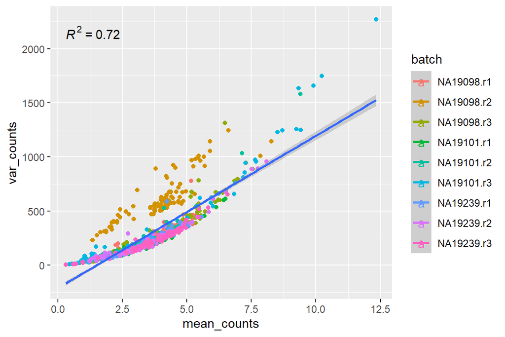

```r
# Now plot
scater::ggcells(experiment, aes(x = mean_counts, y = var_counts, color = batch)) +
  geom_point() +
  stat_smooth(method = "lm", aes(x = mean_counts, y = var_counts, color = NULL)) +
  ggpubr::stat_cor(aes(label = after_stat(rr.label), color = NULL))
```

##### Ok chief but what about interpretation?

> Positive correlation between mean(counts) and var(counts) is typical for RNA-seq, especially raw count data. This is not a good scenario (it’s not really problematic if we know how to deal with it), because a lot of expression/FC estimators and test-s producing p-values and q-values assume that mean and variance are independent variables (no correlation).

### Sensational dimensionality reduction

`Scater` library and `SingleCellExperiment` are tightly bound together, because `Scater` is based on `SingleCellExperiment`. It is very easy to apply some dimensionality reduction techniques and plot some advanced visualization *JUST LIKE THAT*. Let’s try to do some dimensionality reduction:

```r
experiment = scater::runPCA(experiment, ncomponents = 2) # Returns new experiment with a new reducedDim object
print(experiment) # reducedDimNames(1) -> Now containes new entry called "PCA"
```

```
## class: SingleCellExperiment
## dim: 19027 864
## metadata(0):
## assays(2): counts logcounts
## rownames(19027): ENSG00000237683 ENSG00000187634 ... ERCC-00170 ERCC-00171
## rowData names(0):
## colnames(864): NA19098.r1.A01 NA19098.r1.A02 ... NA19239.r3.H11 NA19239.r3.H12
## colData names(9): individual replicate ... total_counts var_counts
## reducedDimNames(1): PCA
## mainExpName: NULL
## altExpNames(0):
```

```r
#  Access reduced dimname using reducedDim() functin
reducedDim(experiment, "PCA")[1:10, ] # first ten rows for clarity
```

```
##                       PC1      PC2
## NA19098.r1.A01 -2.3370751 3.408429
## NA19098.r1.A02 -0.7896852 4.528270
## NA19098.r1.A03 -4.4559639 1.429883
## NA19098.r1.A04 -5.2230930 1.641980
## NA19098.r1.A05 -2.2025377 3.071768
## NA19098.r1.A06 -2.7491796 3.848804
## NA19098.r1.A07 -2.4159921 2.656730
## NA19098.r1.A08 -0.4278657 5.372071
## NA19098.r1.A09 -3.5537904 2.228423
## NA19098.r1.A10 -1.3527432 5.795948
```

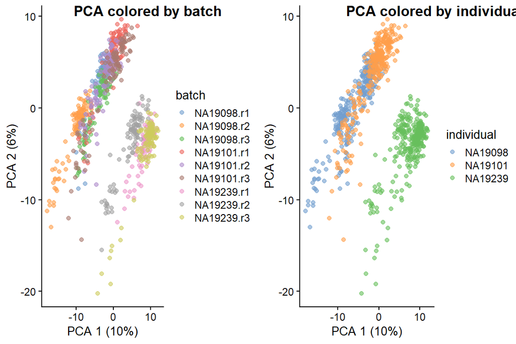

```r
# Maybe plot some PCA?
# First create some plots
# Colour_by is a name of the column in colData -> Remember? colData is data.frame with additional information for each cell.
# We've performed PCA to reduce dimensionality for each *CELL*.
# So no we plot each cell and we can add some information -> that's why I used colour_by = "batch"

batch_pca = scater::plotReducedDim(experiment, "PCA", colour_by = "batch")
ind_pca = scater::plotReducedDim(experiment, "PCA", colour_by = "individual")

ggpubr::ggarrange(batch_pca, ind_pca, labels = c("PCA colored by batch", "PCA colored by individual"), font.label = list(size = 12))
```

So we got the PCA, but it’s not widely used in single-cell. Let’s do umap and tSNE colored by individual

```r
experiment = experiment %>%
  scater::runUMAP() %>%
  scater::runTSNE()
experiment %>% print() # reducedDimNames(3) -> got new entries, named "UMAP" and "TNSE"
```

```
## class: SingleCellExperiment
## dim: 19027 864
## metadata(0):
## assays(2): counts logcounts
## rownames(19027): ENSG00000237683 ENSG00000187634 ... ERCC-00170 ERCC-00171
## rowData names(0):
## colnames(864): NA19098.r1.A01 NA19098.r1.A02 ... NA19239.r3.H11 NA19239.r3.H12
## colData names(9): individual replicate ... total_counts var_counts
## reducedDimNames(3): PCA UMAP TSNE
## mainExpName: NULL
## altExpNames(0):
```

```r
# Lets see new reduced dim
reducedDim(experiment, "UMAP") %>% head() %>% print
```

```
##                    [,1]       [,2]
## NA19098.r1.A01 5.901302  -9.697157
## NA19098.r1.A02 5.757492  -9.889184
## NA19098.r1.A03 6.255654  -9.664281
## NA19098.r1.A04 6.406497  -9.960106
## NA19098.r1.A05 5.685167  -9.896578
## NA19098.r1.A06 6.029984 -10.139025
```

```r
reducedDim(experiment, "TSNE") %>% head() %>% print()
```

```
##                     [,1]     [,2]
## NA19098.r1.A01 -6.015978 18.34679
## NA19098.r1.A02 -6.474809 19.15945
## NA19098.r1.A03 -4.801825 18.33697
## NA19098.r1.A04 -5.671084 16.31681
## NA19098.r1.A05 -6.550621 18.19806
## NA19098.r1.A06 -8.163220 16.61686
```

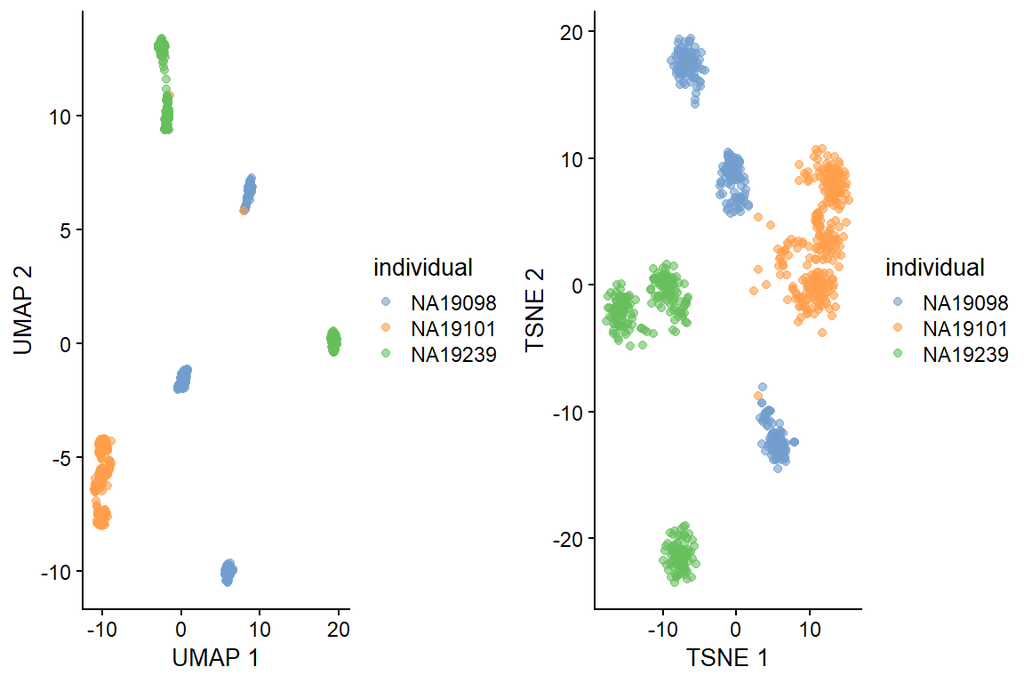

```r
# Ok so let's plot it
ind_umap = scater::plotReducedDim(experiment, "UMAP", colour_by = "individual")
ind_tsne = scater::plotReducedDim(experiment, "TSNE", colour_by = "individual")
ggpubr::ggarrange(ind_umap, ind_tsne)
```

Even more reduced dimensions

```r
# Ok let's do more (lok it's so easy idk why people hate R)
experiment = experiment %>%
  scater::runNMF() %>%
  scater::runMDS()
experiment %>% print() # Lol 2 new entries
```

```
## class: SingleCellExperiment
## dim: 19027 864
## metadata(0):
## assays(2): counts logcounts
## rownames(19027): ENSG00000237683 ENSG00000187634 ... ERCC-00170 ERCC-00171
## rowData names(0):
## colnames(864): NA19098.r1.A01 NA19098.r1.A02 ... NA19239.r3.H11 NA19239.r3.H12
## colData names(9): individual replicate ... total_counts var_counts
## reducedDimNames(5): PCA UMAP TSNE NMF MDS
## mainExpName: NULL
## altExpNames(0):
```

```r
# so now we have all 5 reduced dim entries
reducedDimNames(experiment) %>% print() # [1] "PCA"  "UMAP" "TSNE" "NMF"  "MDS"
```

```
## [1] "PCA"  "UMAP" "TSNE" "NMF"  "MDS"
```

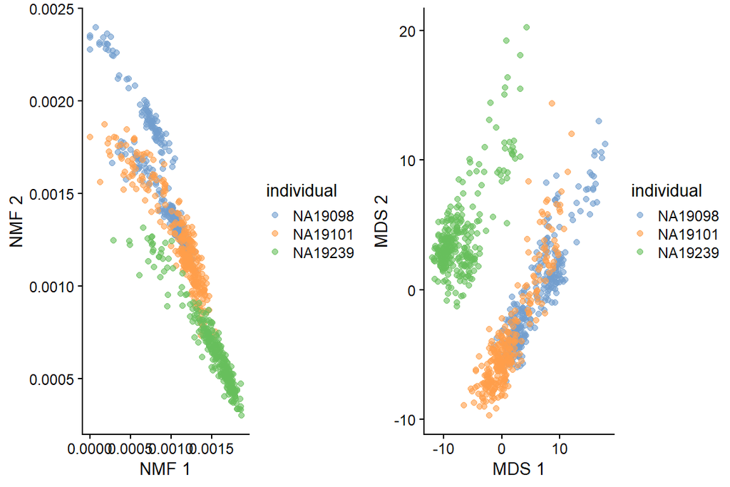

```r
# plot last 2 of them
ind_nmf = scater::plotReducedDim(experiment, "NMF", colour_by = "individual")
ind_mds = scater::plotReducedDim(experiment, "MDS", colour_by = "individual")
ggpubr::ggarrange(ind_nmf, ind_mds)
```

# Real analysis (Dataset load + QC + Low expression filtering)

> Just do it! *~ ur transcriptomics teacher*

## Dataset

```r
# Scater with AnnotationDbi and org.Hs.ed.db to convert EnsemblIDs to gene names
library(scater)
library(SingleCellExperiment)
library(AnnotationDbi)
library(org.Hs.eg.db)
library(EnsDb.Hsapiens.v86)


# In bioconductor we can have a lot of annotation resources. The are Database packages (like normal databases)
# These resources can be GeneCentric or GenomeCentric (annotation on individual genes or whole genomes respectively)
# Gene centric annotations can be:
#   - on organism level: org.Mm.eg.db
#   - on platform level: hgu133plus2.db
#   - on system   level: GO.db
# Genome centric annotations can be:
#   - on transcriptome level:  TxDb.Hsapiens.UCSC.hg19.knownGene (Tx -transcript, Db- database = TranscriptDatabase)
#   - on generic genome features: via GenomicFeatures package
# Resources can also be web-based:
#   - biomart: via biomaRt package

# AnnotationDbi ("i" - interface) is a package that can easily query those databases
# So we have Scater for some useful data analysis, db packages for getting metadata on our genes/genomes
# and AnnotationDbi for all the queries

# AnnotationDbi has methods like normal SQL language (SELECT, etc)
# DB packages, after loading expose an object named exactly the same as the package
# We can use the methods from AnnotationDbi to query db object using SQL methods
#
# Example:
# Types of columns our data has
columns(org.Hs.eg.db) %>% print()
```

```
##  [1] "ACCNUM"       "ALIAS"        "ENSEMBL"      "ENSEMBLPROT"  "ENSEMBLTRANS" "ENTREZID"
##  [7] "ENZYME"       "EVIDENCE"     "EVIDENCEALL"  "GENENAME"     "GENETYPE"     "GO"
## [13] "GOALL"        "IPI"          "MAP"          "OMIM"         "ONTOLOGY"     "ONTOLOGYALL"
## [19] "PATH"         "PFAM"         "PMID"         "PROSITE"      "REFSEQ"       "SYMBOL"
## [25] "UCSCKG"       "UNIPROT"
```

```r
# Types of keys that we can use to fetch the data
keytypes(org.Hs.eg.db) %>% print()
```

```
##  [1] "ACCNUM"       "ALIAS"        "ENSEMBL"      "ENSEMBLPROT"  "ENSEMBLTRANS" "ENTREZID"
##  [7] "ENZYME"       "EVIDENCE"     "EVIDENCEALL"  "GENENAME"     "GENETYPE"     "GO"
## [13] "GOALL"        "IPI"          "MAP"          "OMIM"         "ONTOLOGY"     "ONTOLOGYALL"
## [19] "PATH"         "PFAM"         "PMID"         "PROSITE"      "REFSEQ"       "SYMBOL"
## [25] "UCSCKG"       "UNIPROT"
```

```r
# Fetch keys using "SYMBOL" keytype and print some first keys
keys(org.Hs.eg.db, keytype = "SYMBOL") %>% head() %>% print()
```

```
## [1] "A1BG"  "A2M"   "A2MP1" "NAT1"  "NAT2"  "NATP"
```

```r
# Or another using "ENSEMBL"
keys(org.Hs.eg.db, keytype = "ENSEMBL") %>% head() %>% print()
```

```
## [1] "ENSG00000121410" "ENSG00000175899" "ENSG00000256069" "ENSG00000171428" "ENSG00000156006"
## [6] "ENSG00000196136"
```

```r
# Lets say we want to fetch first 15 genes
# Lets get the first 15 keys (let's use symbol)
qkeys = keys(org.Hs.eg.db, keytype = "SYMBOL") %>% head(15)
print(qkeys)
```

```
##  [1] "A1BG"     "A2M"      "A2MP1"    "NAT1"     "NAT2"     "NATP"     "SERPINA3" "AADAC"    "AAMP"
## [10] "AANAT"    "AARS1"    "AAVS1"    "ABAT"     "ABCA1"    "ABCA2"
```

```r
# SELECT on org.Hs.eg.db using our keys, keytype and return a columns
fetched = select(org.Hs.eg.db, keys = qkeys, keytype = "SYMBOL", columns = c("SYMBOL", "ENSEMBL"))
print(fetched)
```

```
##      SYMBOL         ENSEMBL
## 1      A1BG ENSG00000121410
## 2       A2M ENSG00000175899
## 3     A2MP1 ENSG00000256069
## 4      NAT1 ENSG00000171428
## 5      NAT2 ENSG00000156006
## 6      NATP            <NA>
## 7  SERPINA3 ENSG00000196136
## 8     AADAC ENSG00000114771
## 9      AAMP ENSG00000127837
## 10    AANAT ENSG00000129673
## 11    AARS1 ENSG00000090861
## 12    AAVS1            <NA>
## 13     ABAT ENSG00000183044
## 14    ABCA1 ENSG00000165029
## 15    ABCA2 ENSG00000107331
```

Create our experiment once again. Let’s name it *sce*

```r
sce = SingleCellExperiment(assays = list(counts = as.matrix(molecules)), colData = annotation)
print(sce)
```

```
## class: SingleCellExperiment
## dim: 19027 864
## metadata(0):
## assays(1): counts
## rownames(19027): ENSG00000237683 ENSG00000187634 ... ERCC-00170 ERCC-00171
## rowData names(0):
## colnames(864): NA19098.r1.A01 NA19098.r1.A02 ... NA19239.r3.H11 NA19239.r3.H12
## colData names(5): individual replicate well batch sample_id
## reducedDimNames(0):
## mainExpName: NULL
## altExpNames(0):
```

Now we have to do some magic -> remove RNA spike-ins. But what are they? Acutally RNA spike-ins are synthetic RNA molecules that are added to a sample at a known concentration in order to control for variability in RNA sequencing experiments. They can be used to assess the accuracy and precision of the RNA-sequencing method, and to normalize the data from different samples.

RNA spike-ins are typically made of RNA sequences that are well characterized and have known properties, such as length, GC content, and secondary structure. They can be derived from a variety of sources, including synthetic RNA oligonucleotides or cDNAs, and are typically added to the sample at a concentration that is much lower than the endogenous RNA present in the sample.

So, we have to remove spike-ins from regular assays and store them as an ‘alternative experiment’. Typical examples besided spike-in transcripts can be CRISPR tags in CITE-seq experiments. These data cannot be stored in the main assays of the SingleCellExperiment itself.

```r
# In our dataset spike-ins are annotated as ERCC
# (ERCC RNA spike-in mix, Invitrogen™, ThermoFisher Scientific)
# So (according to SingleCellExperiment schema) we should remove genes (rows)
# that begins with ERCC

# Let's see if we have any
# Get gene names (from rows)
rownames(sce) %>%
  # Construct lambda expr to check if gene name starts with ERCC
  purrr::keep(~ stringr::str_starts(.x, "ERCC")) %>%
  # Take some first
  head() %>%
  # Print it
  print()
```

```
## [1] "ERCC-00002" "ERCC-00003" "ERCC-00004" "ERCC-00009" "ERCC-00012" "ERCC-00013"
```

```r
# Okay so we have some. Now let's extract them from regular assay to alternativeExperiment slot
# Remember! we can index SingleCellExperiment obj using gene names and sample names
ercc_idx = grep(pattern = "^ERCC", rownames(sce)) # indicies of ERCC transcripts
print(ercc_idx %>% length()) # 89 ERCC's, nice
```

```
## [1] 89
```

```r
altExp(sce, "ERCC") <- sce[ercc_idx, ] # Set new alternativeExperiment by indexing sce
print(sce) # altExpNames(1): ERCC - nice
```

```
## class: SingleCellExperiment
## dim: 19027 864
## metadata(0):
## assays(1): counts
## rownames(19027): ENSG00000237683 ENSG00000187634 ... ERCC-00170 ERCC-00171
## rowData names(0):
## colnames(864): NA19098.r1.A01 NA19098.r1.A02 ... NA19239.r3.H11 NA19239.r3.H12
## colData names(5): individual replicate well batch sample_id
## reducedDimNames(0):
## mainExpName: NULL
## altExpNames(1): ERCC
```

```r
# Now remove these ERCC's from regular assays
sce = sce[-ercc_idx, ] # rownames(18938), previously (19027) - nice
```

Now, let’s map ENSEMBL IDs to gene symbols.

```r
# 'mapIds' gets the mapped ids (column) for a set of keys that are of a particular keytype. Usually returned as a named character vector.
# In other words this function queries that db with our keys and returns a column that is mapped to our keys
# So we get something like a dictionary, where key: our serach key, value: returned values
# In this example we use ENSEMBL_IDS from our dataset as keys, and returned value is vector os gene symbols
# where names are our keys. It's like a map, u know XD
gene_names <- mapIds(org.Hs.eg.db, keys=rownames(sce), keytype="ENSEMBL", column="SYMBOL")
print(gene_names %>% head())
```

```
## ENSG00000237683 ENSG00000187634 ENSG00000188976 ENSG00000187961 ENSG00000187583 ENSG00000187642
##              NA        "SAMD11"         "NOC2L"        "KLHL17"       "PLEKHN1"         "PERM1"
```

```r
rowData(sce)$SYMBOL <- gene_names # Add new rowData entry
print(rowData(sce))
```

```
## DataFrame with 18938 rows and 1 column
##                      SYMBOL
##                 <character>
## ENSG00000237683          NA
## ENSG00000187634      SAMD11
## ENSG00000188976       NOC2L
## ENSG00000187961      KLHL17
## ENSG00000187583     PLEKHN1
## ...                     ...
## ENSG00000157828          NA
## ENSG00000183146          NA
## ENSG00000169800      RBMY1F
## ENSG00000183753        BPY2
## ENSG00000172352       CDY1B
```

```r
# Check for na
table(is.na(gene_names))
```

```
##
## FALSE  TRUE
## 18078   860
```

From the table command, we can see that most genes were annotated; however, 860 returned “NA.” By default, mapIds returs one symbol per ID; this behaviour can be changed using multiVals argument( we can take first, last, pass some function, etc). Let’s remove all those NA’s.

```r
sce = sce[!is.na(rowData(sce)$SYMBOL), ]
print(sce)
```

```
## class: SingleCellExperiment
## dim: 18078 864
## metadata(0):
## assays(1): counts
## rownames(18078): ENSG00000187634 ENSG00000188976 ... ENSG00000183753 ENSG00000172352
## rowData names(1): SYMBOL
## colnames(864): NA19098.r1.A01 NA19098.r1.A02 ... NA19239.r3.H11 NA19239.r3.H12
## colData names(5): individual replicate well batch sample_id
## reducedDimNames(0):
## mainExpName: NULL
## altExpNames(1): ERCC
```